# Generating Data For Two By Two Between Subjects

David Allbritton

2024-12-16

Create simulated data for a 2x2 fully randomized (all between-subjects) ANOVA design. The .csv file of simulated data contains a “DV” column of normally distributed (gaussian) data, plus a conversion of that data to a 7-point likert scale and a conversion to a 5-point likert scale.

Whenever you “Knit” this .rmd file in Rstudio, it will create a data file called “simulated_data.csv”, and it will create an .html file that shows some diagnostics and analyses using the simulated data.

```r
################################
## Define parameters; change this part as needed
n                  <- 25 # Number of subjects per condition
Baseline_Mean      <- 10 # Grand mean
effect_size_A      <- -.5  # Effect size for factor A in Cohen's d units
effect_size_B      <- .5  # Effect size for factor B in Cohen's d units
effect_size_AB     <- .2  # Effect size for interaction A*B in Cohen's d units
sd_error           <- 2  # Standard deviation for generating gaussian simulated data
randseed           <- 0  # if > 0, sets the random number seed for reproducibility; otherwise different data is generated each time
################################
```

```r
# scale the effect sizes by the chosen standard deviation; do not change this part
effect_A      <- effect_size_A * sd_error
effect_B      <- effect_size_B * sd_error
effect_AB     <- effect_size_AB * sd_error
```

```r
if(randseed > 0) set.seed(randseed)
```

```r
# load libraries and functions
library(car)
library(dplyr)
library(sjstats)
```

```r
library(ggplot2)

#######  Define custom functions #######

################
# function to convert eta squared to d
# formula:   d = 2 * sqrt(es / (1 - es))
#   where d = cohen's d, es = eta squared from a two-group design (or a single df contrast)
eta_sq_to_d <- function(es) {
  d <- 2 * sqrt(es / (1-es))
  d
}

################

effect_direction <- function(data, effect) {
  # Ensure valid effect input
  if (!effect %in% c("A", "B", "AB")) {
    stop("Effect must be one of 'A', 'B', or 'AB'")
  }

  # For main effect of A
  if (effect == "A") {
    mean_A1 <- mean(data$DV[data$A == "A1"])
    mean_A2 <- mean(data$DV[data$A == "A2"])
    return(ifelse(mean_A1 <= mean_A2, 1, -1))
  }

  # For main effect of B
  if (effect == "B") {
    mean_B1 <- mean(data$DV[data$B == "B1"])
    mean_B2 <- mean(data$DV[data$B == "B2"])
    return(ifelse(mean_B1 <= mean_B2, 1, -1))
  }

  # For interaction effect AB
  if (effect == "AB") {
    mean_A1B1 <- mean(data$DV[data$A == "A1" & data$B == "B1"])
    mean_A1B2 <- mean(data$DV[data$A == "A1" & data$B == "B2"])
    mean_A2B1 <- mean(data$DV[data$A == "A2" & data$B == "B1"])
    mean_A2B2 <- mean(data$DV[data$A == "A2" & data$B == "B2"])

    interaction_A1 <- mean_A1B2 - mean_A1B1
    interaction_A2 <- mean_A2B2 - mean_A2B1

    return(ifelse(interaction_A2 >= interaction_A1, 1, -1))
  }
}
#################
```

## Generating Data for a 2x2 fully randomized (between subjects) factorial design

First, let’s see what gpt4o comes up with for us. It sort of worked, but I had to adjust the way it handles the interaction term.

```r
# Create a 2x2 factorial design
simulated_data <- expand.grid(A = c("A1", "A2"), B = c("B1", "B2"))
simulated_data <- simulated_data[rep(1:nrow(simulated_data), each = n), ]
simulated_data$Subject <- 1:nrow(simulated_data)

# Generate gaussian data
simulated_data$DV <- with(simulated_data, {
  mu <- Baseline_Mean # Baseline mean
  mu <- mu - (A == "A1") * effect_A /2     # Add effect of A
  mu <- mu + (A == "A2") * effect_A /2    # Add effect of A
  mu <- mu - (B == "B1") * effect_B  /2    # Add effect of B
  mu <- mu + (B == "B2") * effect_B  /2    # Add effect of B
  mu <- mu - (A == "A1" & B == "B2") * effect_AB /2 # Add interaction
  mu <- mu + (A == "A2" & B == "B2") * effect_AB /2 # Add interaction
  mu <- mu + (A == "A1" & B == "B1") * effect_AB /2 # Add interaction
  mu <- mu - (A == "A2" & B == "B1") * effect_AB /2 # Add interaction
  rnorm(nrow(simulated_data), mean = mu, sd = sd_error) # Add Gaussian noise
})

# Convert factors to factor type
simulated_data$A <- factor(simulated_data$A)
simulated_data$B <- factor(simulated_data$B)
```

Add a column of Likert scale ratings (1-7) that could result from the underlying gaussian dv being measured categorically:

```r
# Add a categorical column to the dataset based on evenly spaced intervals
simulated_data$DV_likert7 <- cut(simulated_data$DV,
                                     breaks = seq(min(simulated_data$DV),
                                                  max(simulated_data$DV),
                                                  length.out = 8),
                                     labels = 1:7,
                                     include.lowest = TRUE)
# make it numeric rather than a factor
simulated_data$DV_likert7 <- as.numeric(as.character(simulated_data$DV_likert7))
```

Add another column translating it to a 1-5 Likert scale:

```r
# Add a categorical column to the dataset based on evenly spaced intervals
simulated_data$DV_likert5 <- cut(simulated_data$DV,
                                     breaks = seq(min(simulated_data$DV),
                                                  max(simulated_data$DV),
                                                  length.out = 6),
                                     labels = 1:5,
                                     include.lowest = TRUE)
# make it numeric rather than a factor
simulated_data$DV_likert5 <- as.numeric(as.character(simulated_data$DV_likert5))

# View the updated dataset
head(simulated_data)
```

```
##      A  B Subject        DV DV_likert7 DV_likert5
## 1   A1 B1       1  9.684821          4          3
## 1.1 A1 B1       2 10.822493          4          3
## 1.2 A1 B1       3 10.523429          4          3
## 1.3 A1 B1       4 11.922535          5          4
## 1.4 A1 B1       5 10.827449          4          3
## 1.5 A1 B1       6 11.577728          5          4
```

Write the simulated data to a file

```r
# Save the simulated data to a CSV file
write.csv(simulated_data, file = "simulated_data.csv", row.names = FALSE)
```

Check the cell means of each version of the DV to make sure it looks right:

```r
# Load dplyr
library(dplyr)

# Calculate cell means and standard deviations for the original gaussian DV
cell_stats <- simulated_data %>%
  group_by(A, B) %>%
  summarize(
    Mean = mean(DV),
    SD = sd(DV),
    .groups = "drop"
  )
# Display the results
print(cell_stats)
```

```
## # A tibble: 4 × 4
##   A     B      Mean    SD
##   <fct> <fct> <dbl> <dbl>
## 1 A1    B1    10.7   2.10
## 2 A1    B2    10.7   1.76
## 3 A2    B1     9.00  2.35
## 4 A2    B2    10.1   2.17
```

```r
# Calculate cell means and standard deviations for the 1-7 likert scale DV
cell_stats7 <- simulated_data %>%
  group_by(A, B) %>%
  summarize(
    Mean = mean(DV_likert7),
    SD = sd(DV_likert7),
    .groups = "drop"
  )
# Display the results
print(cell_stats7)
```

```
## # A tibble: 4 × 4
##   A     B      Mean    SD
##   <fct> <fct> <dbl> <dbl>
## 1 A1    B1     4.36  1.47
## 2 A1    B2     4.4   1.22
## 3 A2    B1     3.12  1.62
## 4 A2    B2     3.96  1.57
```

```r
# Calculate cell means and standard deviations for the 1-5 likert scale DV
cell_stats5 <- simulated_data %>%
  group_by(A, B) %>%
  summarize(
    Mean = mean(DV_likert5),
    SD = sd(DV_likert5),
    .groups = "drop"
  )
# Display the results
print(cell_stats5)
```

```
## # A tibble: 4 × 4
##   A     B      Mean    SD
##   <fct> <fct> <dbl> <dbl>
## 1 A1    B1     3.24 1.13
## 2 A1    B2     3.28 0.980
## 3 A2    B1     2.32 1.22
## 4 A2    B2     2.88 1.20
```

Great, now let’s analyze it, first using the underlying gaussian DV:

```r
library(car)

# Setting contrasts for sum-to-zero coding; type III sums of squares do not work sensibly with the default "treatment" contrasts
# setting the contrasts option here will set it for the whole session:
options(contrasts = c("contr.sum", "contr.poly"))

anova_result <- Anova(lm(DV ~ A * B, data = simulated_data), type = "III")
anova_result
```

```
## Anova Table (Type III tests)
##
## Response: DV
##              Sum Sq Df   F value    Pr(>F)
## (Intercept) 10289.3  1 2322.5606 < 2.2e-16 ***
## A              35.7  1    8.0568  0.005532 **
## B               7.4  1    1.6666  0.199816
## A:B             7.5  1    1.6954  0.196006
## Residuals     425.3 96
## ---
## Signif. codes:  0 '***' 0.001 '**' 0.01 '*' 0.05 '.' 0.1 ' ' 1
```

Then do the same analysis using the categorical 1-7 rating scale version of the DV:

```r
# Run the ANOVA
anova_result7 <- Anova(lm(DV_likert7 ~ A * B, data = simulated_data), type = "III")
anova_result7
```

```
## Anova Table (Type III tests)
##
## Response: DV_likert7
##              Sum Sq Df  F value    Pr(>F)
## (Intercept) 1568.16  1 719.0646 < 2.2e-16 ***
## A             17.64  1   8.0887  0.005444 **
## B              4.84  1   2.2193  0.139570
## A:B            4.00  1   1.8342  0.178816
## Residuals    209.36 96
## ---
## Signif. codes:  0 '***' 0.001 '**' 0.01 '*' 0.05 '.' 0.1 ' ' 1
```

Then do the same analysis using the categorical 1-5 rating scale version of the DV:

```r
# Run the ANOVA
anova_result5 <- Anova(lm(DV_likert5 ~ A * B, data = simulated_data), type = "III")
anova_result5
```

```
## Anova Table (Type III tests)
##
## Response: DV_likert5
##             Sum Sq Df  F value    Pr(>F)
## (Intercept) 858.49  1 666.3571 < 2.2e-16 ***
## A            10.89  1   8.4528  0.004527 **
## B             2.25  1   1.7464  0.189465
## A:B           1.69  1   1.3118  0.254921
## Residuals   123.68 96
## ---
## Signif. codes:  0 '***' 0.001 '**' 0.01 '*' 0.05 '.' 0.1 ' ' 1
```

```r
library(sjstats)
# Extract effect sizes
eta_squared <- effectsize::eta_squared(anova_result, partial = FALSE) # Full Eta-squared
```

```
## Type 3 ANOVAs only give sensible and informative results when covariates
##   are mean-centered and factors are coded with orthogonal contrasts (such
##   as those produced by `contr.sum`, `contr.poly`, or `contr.helmert`, but
##   *not* by the default `contr.treatment`).
```

```r
partial_eta_squared <- effectsize::eta_squared(anova_result, partial = TRUE) # Partial Eta-squared
```

```
## Type 3 ANOVAs only give sensible and informative results when covariates
##   are mean-centered and factors are coded with orthogonal contrasts (such
##   as those produced by `contr.sum`, `contr.poly`, or `contr.helmert`, but
##   *not* by the default `contr.treatment`).
```

```r
# add a column for Cohen's d and display the results
#effectSizes <- eta_squared
#effectSizes <- effectSizes %>% mutate(d = eta_sq_to_d(Eta2))  # using the previously defined function
#effectSizes
```

Effect sizes that were actually used to generate the simulated data

```r
# print the actual effect sizes that were used to generate the simulated data:
print(effect_size_A)
```

```
## [1] -0.5
```

```r
print(effect_size_B)
```

```
## [1] 0.5
```

```r
print(effect_size_AB)
```

```
## [1] 0.2
```

Effect sizes observed in analysis of the simulated data

```r
effectSizes2 <- partial_eta_squared
effectSizes2 <- effectSizes2 %>% mutate(d = eta_sq_to_d(Eta2_partial))  # using the previously defined function
effectSizes2
```

```
## # Effect Size for ANOVA
##
## Parameter | Eta2 (partial) |       95% CI |    d
## ------------------------------------------------
## A         |           0.08 | [0.01, 1.00] | 0.58
## B         |           0.02 | [0.00, 1.00] | 0.26
## A:B       |           0.02 | [0.00, 1.00] | 0.27
```

```r
    # determine whether effect sizes are positive or negative
    data <- simulated_data
    partial_eta <- effectSizes2
    sign_A <- effect_direction(data, "A")
    sign_B <- effect_direction(data, "B")
    sign_AB <- effect_direction(data, "AB")
    signs <- c(sign_A, sign_B, sign_AB)
    partial_eta$signs <- signs
    partial_eta <- partial_eta %>% mutate(d = signs * 2 * sqrt(Eta2_partial / (1 - Eta2_partial)))
    # re-read the inputs for the true effect sizes
      true_ds <- c(effect_size_A, effect_size_B, effect_size_AB)
    partial_eta$"True d" <- true_ds
    partial_eta %>% select(Parameter,   Eta2_partial,   d, "True d")
```

```
## # Effect Size for ANOVA
##
## Parameter | Eta2 (partial) |     d | True d
## -------------------------------------------
## A         |           0.08 | -0.58 |  -0.50
## B         |           0.02 |  0.26 |   0.50
## A:B       |           0.02 |  0.27 |   0.20
```

```r
cell_stats
```

```
## # A tibble: 4 × 4
##   A     B      Mean    SD
##   <fct> <fct> <dbl> <dbl>
## 1 A1    B1    10.7   2.10
## 2 A1    B2    10.7   1.76
## 3 A2    B1     9.00  2.35
## 4 A2    B2    10.1   2.17
```

```r
simulated_data$DV %>% mean()
```

```
## [1] 10.14362
```

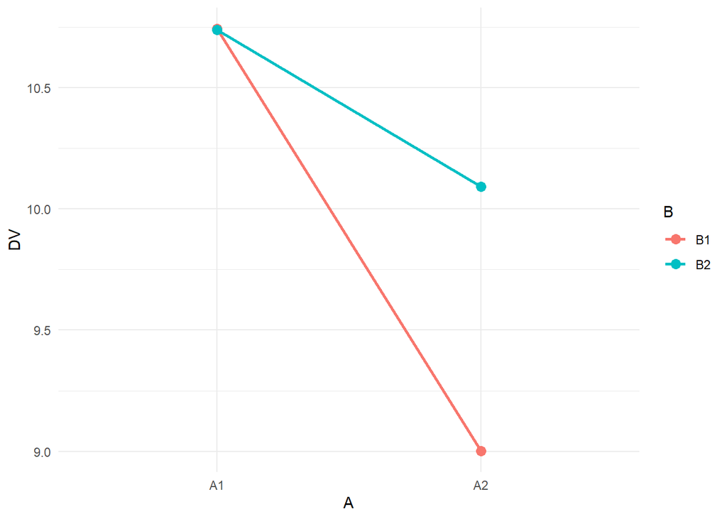

```r
simulated_data %>%
  select(A, B, DV) %>%
  ggplot(aes(x = A, y = DV, color = B, group = B)) +
  stat_summary(fun = mean, geom = "line", size = 1) +  # Lines connecting group means
  stat_summary(fun = mean, geom = "point", size = 3) +
  theme_minimal()
```